# Predictors of body mass in African ungulates

2025-12-09

# 1 Introduction

Body mass is known to be an important predictor of individual health and population longevity, however what variables affect body mass is less understood (Clements & Ozgul 2016, Cerini et al. 2023). Knowledge of these interactions is essential to wildlife conservation efforts as it could play a key role in conservation strategy and the maintenance of healthy populations, for example in the management of ungulate species in Africa. These animals play an essential role in maintaining ecosystems so ensuring healthy populations remains an ongoing priority. A Generalised Linear Mixed-effect Model (GLMM) has been developed here, to better understand the impact of a select number of environmental factors on body mass.

# 2 Preparation

## 2.1 Required packages

The packages below are required for raw data processing and exploration, model formulation, and results interpretation and presentation.

```r
# load required packages
library(vroom)
library(Hmisc)
library(tidyverse)
library(rstatix)
library(patchwork)
library(fitdistrplus)
library(tweedie)
library(glmmTMB)
library(MuMIn)
library(DHARMa)
library(broom.mixed)
library(modelbased)
library(parameters)
library(ggeffects)
```

## 2.2 The data

The `vroom()` function was used to read in the data on African ungulates, and the data was saved as a new object called `au_data` (African ungulate data).

```r
# set working directory
setwd('/Users/macbook/Documents/university/african_ungulates')

# load African ungulate data and saved as new object
au_data <- vroom('mass_px25585.tsv')
```

# 3 Data tidying

## 3.1 Understanding the data

The first step in tidying the dataset is to understand it, and to that end the `class()` and `described()` functions from the `Hmisc` package were used here to understand the structure of the data and identify any incorrectly input values.

```r
# understand the data structure
class(au_data)
```

```
## [1] "spec_tbl_df" "tbl_df"      "tbl"         "data.frame"
```

The `class()` function shows that the data has four classes, three of which include `tbl` meaning tibble which is the output from vroom. The final class is `data.frame`.

```r
# identify incorrect values and variables
describe(au_data)
```

```
## au_data
##
##  10  Variables      870  Observations
## --------------------------------------------------------------------------------
## student_id
##        n  missing distinct    value
##      870        0        1  px25585
##
## Value      px25585
## Frequency      870
## Proportion       1
## --------------------------------------------------------------------------------
## species
##        n  missing distinct    value
##      870        0        1  Giraffe
##
## Value      Giraffe
## Frequency      870
## Proportion       1
## --------------------------------------------------------------------------------
## park
##        n  missing distinct
##      870        0        4
##
## Value           Golden Tusk Safari    Lionshade Wilderness
## Frequency                      264                     186
## Proportion                   0.303                   0.214
##
## Value      Savanna Whisper Reserve      Zebra Horizon Park
## Frequency                      189                     231
## Proportion                   0.217                   0.266
## --------------------------------------------------------------------------------
## observer
##        n  missing distinct
##      870        0        5
##
## Value      Obs_1 Obs_2 Obs_3 Obs_4 Obs_5
## Frequency    147   204   159   183   177
## Proportion 0.169 0.234 0.183 0.210 0.203
## --------------------------------------------------------------------------------
```

[output cut: 39 more lines]

```
## Proportion                      0.333                      0.333
##
## Value      predator_density_per_sq_km
## Frequency                         290
## Proportion                      0.333
## --------------------------------------------------------------------------------
## env_value
##         n   missing  distinct      Info      Mean   pMedian       Gmd       .05
##       862         8       862         1     334.9     317.5     481.3    0.4668
##       .10       .25       .50       .75       .90       .95
##    0.6515    1.2368    3.5664  795.3547 1161.8979 1290.3489
##
## lowest : 0.101891 0.167874 0.172813 0.228129 0.259863
## highest: 1712.42  1714.88  1729.07  1737.42  1807.51
## --------------------------------------------------------------------------------
```

The `describe()` function revealed some likely typos under the `lion_presence` column, with instances of “Asbent” clearly representing “Absent” and those of “Preesnt” and “Preseet” representing “Present”.

## 3.2 Corrections

Corrections were made as follows.

```r
# make corrections
au_data$lion_presence[au_data$lion_presence=="Asbent"]<-"Absent"
au_data$lion_presence[au_data$lion_presence=="Preesnt"]<-"Present"
au_data$lion_presence[au_data$lion_presence=="Preseet"]<-"Present"
```

## 3.3 Readying for analysis

In addition to the typos now corrected, `describe()` revealed that the column `env_var` contains three variables (`average_annual_rainfall_mm`, `distance_to_water_km`, and `predator_density_per_sq_km`) that have corresponding values under `env_value`. To more easily manipulate the data, each environmental variable needs to have its own column of corresponding values. This change was implemented using the `pivot_wider()` function from the `dplyr` package. At this stage NA values were also been dropped, as they would cause problems when performing GLMM analyses, and the `student_id` and `species` columns were removed, as they are the same for all data samples.

```r
# define new tidied data object and take African ungulates data as input
tidy_au <- au_data %>%
  # create columns for each environmental variable and their associated values
  # use pivot wider to change env_var to columns containing values from env_value
  pivot_wider(names_from = env_var,
              values_from = env_value) %>%
  # remove rows with na values
  drop_na() %>%
  # remove irrelevant columns
  dplyr::select(-student_id, -species)
```

The absence of duplicate values was confirmed as follows.

```r
tidy_au %>%
  group_by(body_mass) %>%
  filter(n()>1)
```

```
## # A tibble: 0 × 9
## # Groups:   body_mass [0]
## # ℹ 9 variables: park <chr>, observer <chr>, body_mass <dbl>, landscape <chr>,
## #   vegetation <chr>, lion_presence <chr>, distance_to_water_km <dbl>,
## #   average_annual_rainfall_mm <dbl>, predator_density_per_sq_km <dbl>
```

No such entries were present.

## 3.4 Analysis model and variables

The `names()` function gives the names of each column in the data (i.e. the variables that can be examined).

```r
names(tidy_au)
```

```
## [1] "park"                       "observer"
## [3] "body_mass"                  "landscape"
## [5] "vegetation"                 "lion_presence"
## [7] "distance_to_water_km"       "average_annual_rainfall_mm"
## [9] "predator_density_per_sq_km"
```

# 4 Raw data exploration

## 4.1 Extreme outlier identification

It is important to identify any extreme outliers that may be present in the continuous numerical data and deal with them appropriately, as these can cause dispersion issues when fitting a GLMM. Here, the the presence of outliers was investigated using dotplots as described by Cleveland (1993).

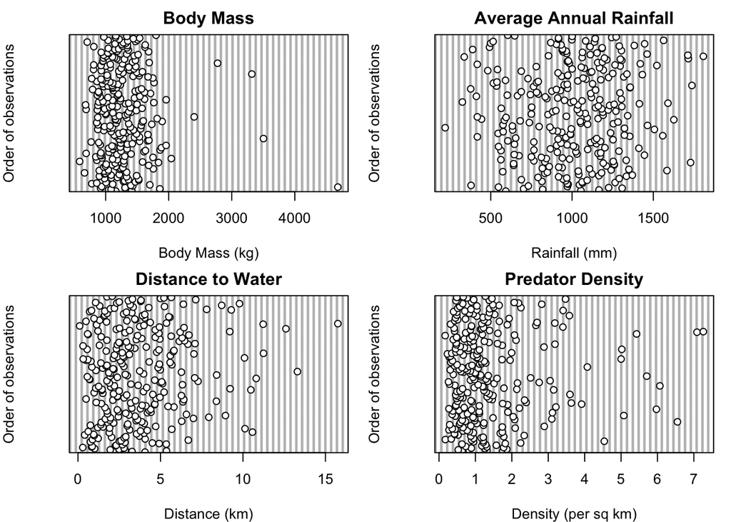

```r
# set up a 4-panel plot to visualise outliers in continuous variables
par(mfrow = c(2, 2), mar = c(4, 4, 2, 1))

# body mass
dotchart(tidy_au$body_mass,
         # tile
         main = "Body Mass",
         # x axis label
         xlab = "Body Mass (kg)",
         # y axis label
         ylab = "Order of observations")

# average annual rainfall
dotchart(tidy_au$average_annual_rainfall_mm,
         main = "Average Annual Rainfall",
         xlab = "Rainfall (mm)",
         ylab = "Order of observations")

# distance to water
dotchart(tidy_au$distance_to_water_km,
         main = "Distance to Water",
         xlab = "Distance (km)",
         ylab = "Order of observations")

# predator density per
dotchart(tidy_au$predator_density_per_sq_km,
         main = "Predator Density",
         xlab = "Density (per sq km)",
         ylab = "Order of observations")
```

```r
# reset plotting parameters
par(mfrow = c(1, 1))
```

For most of the variables it is hard to determine the presence of any outliers but for body mass, it can be seen that the majority of values fall around the 2000kg mark and under apart from 5-6 values that lie beyond this. There is a very high likelihood that the extreme outliers within this group have been input erroneously as Giraffe body weight isn’t generally known to exceed ~2000kg (Herbison and Frame, 2025). Outliers were confirmed using the `identify_outliers()` function from the `rstatix` package, keeping only the extreme values from within the group, which were then removed from the dataset.

```r
# identify outlier values
outlier_values <- identify_outliers(data=tidy_au, variable="body_mass")

# filter for extreme values
extreme_outliers <- outlier_values %>%
  filter(is.extreme == TRUE)

# remove rows in the tidied data that match the outlier values
extdrop_au <- anti_join(tidy_au, extreme_outliers)
```

[output not shown]

## 4.2 Predictor collinearity

Correlation between predictor variables complicates interpretation of partial affects and reduces the validity of effect estimates, so collinearity in this data was assessed as follows.

```r
# inspection of continuous vs continuous variables using scatter plots

# average annual rainfall vs distance to water
# create plot with extdrop data, and assign x and y values to variables being compared
ggplot(extdrop_au, aes(x = average_annual_rainfall_mm, y = distance_to_water_km)) +
  # create scatter plot
  geom_point() +
  # add header
  ggtitle("Check collinearity: Rainfall vs Distance to Water")

# average annual rainfall vs predator density
ggplot(extdrop_au, aes(x = average_annual_rainfall_mm, y = predator_density_per_sq_km)) +
  geom_point() +
  ggtitle("Check collinearity: Rainfall vs Predator Density")

# distance to water vs predator density
ggplot(extdrop_au, aes(x = distance_to_water_km, y = predator_density_per_sq_km)) +
  geom_point() +
  ggtitle("Check collinearity: Distance vs Predator Density")


# inspection of categorical vs continuous variables using boxplots plots

# landscape vs average annual rainfall
# create plot with extdrop data, and assign x and y values to variables being compared
ggplot(extdrop_au, aes(x = landscape, y = average_annual_rainfall_mm)) +
  # create box plot
  geom_boxplot() +
  # add header
  ggtitle("Rainfall by Landscape")

# landscape vs distance to water
ggplot(extdrop_au, aes(x = landscape, y = distance_to_water_km)) +
  geom_boxplot() +
  ggtitle("Distance to Water by Landscape")

# landscape vs predator density
ggplot(extdrop_au, aes(x = landscape, y = predator_density_per_sq_km)) +
  geom_boxplot() +
  ggtitle("Predator Density by Landscape")

# vegetation vs average annual rainfall
ggplot(extdrop_au, aes(x = vegetation, y = average_annual_rainfall_mm)) +
  geom_boxplot() +
  ggtitle("Rainfall by Vegetation")

# vegetation vs distance to water
ggplot(extdrop_au, aes(x = vegetation, y = distance_to_water_km)) +
  geom_boxplot() +
  ggtitle("Distance to Water by Vegetation")

# vegetation vs predator density
ggplot(extdrop_au, aes(x = vegetation, y = predator_density_per_sq_km)) +
  geom_boxplot() +
  ggtitle("Predator Density by Vegetation")

# lion presence vs average annual rainfall
ggplot(extdrop_au, aes(x = lion_presence, y = average_annual_rainfall_mm)) +
  geom_boxplot() +
  ggtitle("Rainfall by Lion Presence")

# lion presence vs distance to water
ggplot(extdrop_au, aes(x = lion_presence, y = distance_to_water_km)) +
  geom_boxplot() +
  ggtitle("Distance to Water by Lion Presence")

# lion presence vs predator density
ggplot(extdrop_au, aes(x = lion_presence, y = predator_density_per_sq_km)) +
  geom_boxplot() +
  ggtitle("Predator Density by Lion Presence")

# inspection of categorical vs categorical variables using tables and mosaic plots

# landscape vs vegetation
# create table comparing variables to each other
table(extdrop_au$landscape, extdrop_au$vegetation)
# use table to create mosaic plot
mosaicplot(table(extdrop_au$landscape, extdrop_au$vegetation),
           # add header
           main = "Landscape vs Vegetation",
           # add x axis label
           xlab = "Landscape",
           # add y axis label
           ylab = "Vegetation")

# landscape vs lion presence
table(extdrop_au$landscape, extdrop_au$lion_presence)
mosaicplot(table(extdrop_au$landscape, extdrop_au$lion_presence),
           main = "Landscape vs Lion Presence",
           xlab = "Landscape",
           ylab = "Lion Presence")

# vegetation vs lion presence
table(extdrop_au$vegetation, extdrop_au$lion_presence)
mosaicplot(table(extdrop_au$vegetation, extdrop_au$lion_presence),
           main = "Vegetation vs Lion Presence",
           xlab = "Vegetation",
           ylab = "Lion Presence")
```

[output not shown]

Fortunately, no significant collinearity appears to be present in the data.

## 4.3 Predictor-response relationships

A pairwise comparison between predictor and response variables was then conducted to identify potential relationships. LOcally Estimated Scatterplot (LOESS) Smoothing was used to create a curved line in case relationships could be identified that weren’t linear. The standard error was also included.

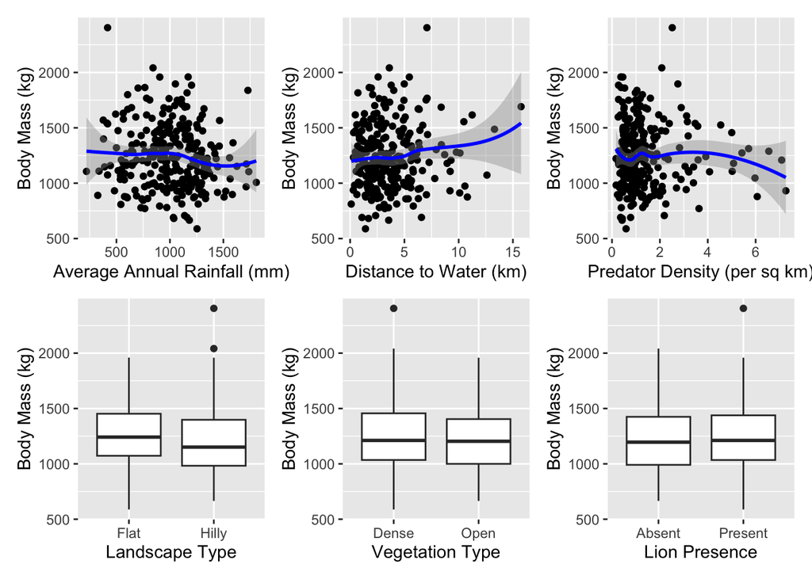

```r
# response vs continuous predictors using scatter plots

# body mass vs average annual rainfall
# create plot with extdrop data, and assign x and y to variables being compared
p1 <- ggplot(extdrop_au, aes(x = average_annual_rainfall_mm, y = body_mass)) +
  # create scatter plot
  geom_point() +
  # add smoothed line with shaded confidence band showing standard error
  geom_smooth(method = "loess", se = TRUE, color = "blue") +
  # add x axis label
  xlab("Average Annual Rainfall (mm)") +
  # add y axis label
  ylab("Body Mass (kg)")

# body mass vs distance to water
p2 <- ggplot(extdrop_au, aes(x = distance_to_water_km, y = body_mass)) +
  geom_point() +
  geom_smooth(method = "loess", se = TRUE, color = "blue") +
  xlab("Distance to Water (km)") +
  ylab("Body Mass (kg)")

# body mass vs predator density
p3 <- ggplot(extdrop_au, aes(x = predator_density_per_sq_km, y = body_mass)) +
  geom_point() +
  geom_smooth(method = "loess", se = TRUE, color = "blue") +
  xlab("Predator Density (per sq km)") +
  ylab("Body Mass (kg)")

# response vs categorical predictors using boxplots

# body mass vs landscape
# create plot with extdrop data, and assign x and y to variables being compared
p4 <- ggplot(extdrop_au, aes(x = landscape, y = body_mass)) +
  # create boxplot
  geom_boxplot() +
  # add x axis label
  xlab("Landscape Type") +
  # add y axis label
  ylab("Body Mass (kg)")

# body mass vs vegetation
p5 <- ggplot(extdrop_au, aes(x = vegetation, y = body_mass)) +
  geom_boxplot() +
  xlab("Vegetation Type") +
  ylab("Body Mass (kg)")

# body mass vs lion presence
p6 <- ggplot(extdrop_au, aes(x = lion_presence, y = body_mass)) +
  geom_boxplot() +
  xlab("Lion Presence") +
  ylab("Body Mass (kg)")

# combine plots in a 2x3 grid
(p1 | p2 | p3) / (p4 | p5 | p6)
```

There doesn’t appear to be any *clear* relationship between body mass and any of the predictor variables alone but body mass does appear to increase slightly as distance to water increases but standard error also increases.

## 4.4 Error distribution candidates

Some of the most likely distributions were tested using the `fitdist()` function from the `fitdistrplus` package. A `tweedie` distribution was also considered at this stage but is not supported by the function.

```r
# test distributions
norm_au <- fitdist(extdrop_au$body_mass, dist = 'norm')
gamma_au <- fitdist(extdrop_au$body_mass, dist = 'gamma')
lnorm_au <- fitdist(extdrop_au$body_mass, dist = 'lnorm')

# compare the distributions
gofstat(list(norm_au, gamma_au, lnorm_au))
```

```
## Goodness-of-fit statistics
##                              1-mle-norm 2-mle-gamma 3-mle-lnorm
## Kolmogorov-Smirnov statistic 0.05770693  0.03480699  0.02627284
## Cramer-von Mises statistic   0.23063326  0.05187336  0.02910731
## Anderson-Darling statistic   1.39876037  0.33821477  0.22809913
##
## Goodness-of-fit criteria
##                                1-mle-norm 2-mle-gamma 3-mle-lnorm
## Akaike's Information Criterion   3835.126    3820.144    3819.560
## Bayesian Information Criterion   3842.323    3827.340    3826.756
```

From these results, it can be seen that the lognormal distribution outperforms the others in all goodness-of-fit tests. However, the lognormal distribution involves transforming the response variable which should be avoided if possible, unless biologically justifiable. For that reason, the gamma distribution has been selected for the initial model formulation (Santon et al., 2023).

# 5 Model formulation

## 5.1 Standardisation of numerical predictors

Numerical predictors have different scales and units, so standardisation can help prevent issues with model convergence, while facilitating comparisons of coefficient estimates between predictors, and ensuring the estimation of covariate intercepts at their population mean value (Santon et al., 2023). The `scale()` function was used to standardise continuous variables to give `aar`, `dtw`, and `pd`.

```r
extdrop_au$aar <- scale(extdrop_au$average_annual_rainfall_mm)
extdrop_au$dtw <- scale(extdrop_au$distance_to_water_km)
extdrop_au$pd <- scale(extdrop_au$predator_density_per_sq_km)
```

## 5.2 Initial model formulation

When formulating an initial GLMM, all predictor variables from the dataset were included as fixed effects, as well as interactions between `vegetation` and `aar` and between `lion_presence` and `pd` as these the multiplicative effect of these interactions was determined to be biologically relevant. `observer` was included as a random intercept effect to account for any difference in observers when recording measurements. `park` was not included in the model as there are only 4 levels of data in the variable, when the minimum required to reliably estimate between-level variance is generally considered to be 5-6 (Santon et al., 2023). The `gamma` distribution was selected, with `log` as the link function.

```r
# define initial gamma glmm and select fixed and random effects
gam1_glmm_au <- glmmTMB(body_mass ~ landscape +
                          vegetation +
                          lion_presence +
                          aar +
                          dtw +
                          pd +
                          vegetation:aar +
                          lion_presence:pd +
                          (1|observer),
                        # input extreme value drop data
                        data = extdrop_au,
                        # select gamma as the distribution with log as the link function
                        family = Gamma(link = "log"))
```

A `tweedie` distribution was also applied to these model parameters as shown below but this failed to converge so was abandoned.

```r
# apply tweedie distribution
twed1_glmm_au <- update(gam1_glmm_au, family="tweedie")
```

## 5.3 Initial model assessment

### 5.3.1 Residuals

To determine whether residuals are independent of predicted mean values and distribute homogenously across all predictor combinations, the `simulateResiduals()` function from the `DHARMa` package was used here to asses residuals.

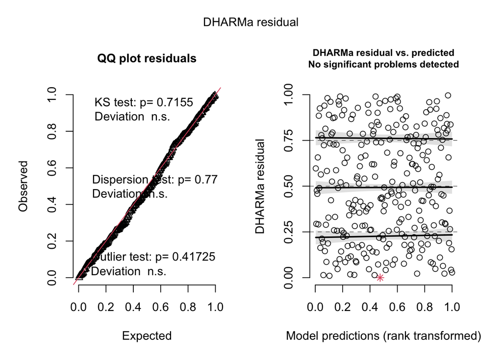

```r
# simulate and plot the model residuals
gam1_sim_au <- simulateResiduals(gam1_glmm_au, n = 1000, plot=T)
```

There is no significant deviation in the QQ plot of observed vs expected residuals, meaning the residuals follow the expected distribution, and the points of the DHARMa residuals vs predicted plot are homogeneously distributed, meaning variance is constant across predicted values.

To examine dispersion of the model residuals, the `testDispersion` function was used.

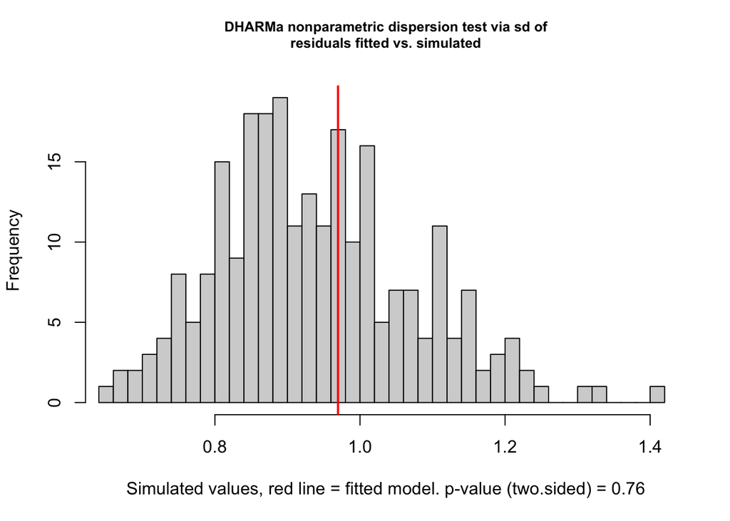

```
##
##  DHARMa nonparametric dispersion test via sd of residuals fitted vs.
##  simulated
##
## data:  simulationOutput
## dispersion = 1.0314, p-value = 0.76
## alternative hypothesis: two.sided
```

```r
# test the dispersion of the model residuals
testDispersion(gam1_glmm_au,plot=T)
```

The model does not appear to be under- or over-dispersed, with no significant difference being found between fitted and simulated residuals (p>0.76).

### 5.3.2 Outlier values

To identify remaining outlier values and examine how the model deals with outliers the `testOutliers()` function was used.

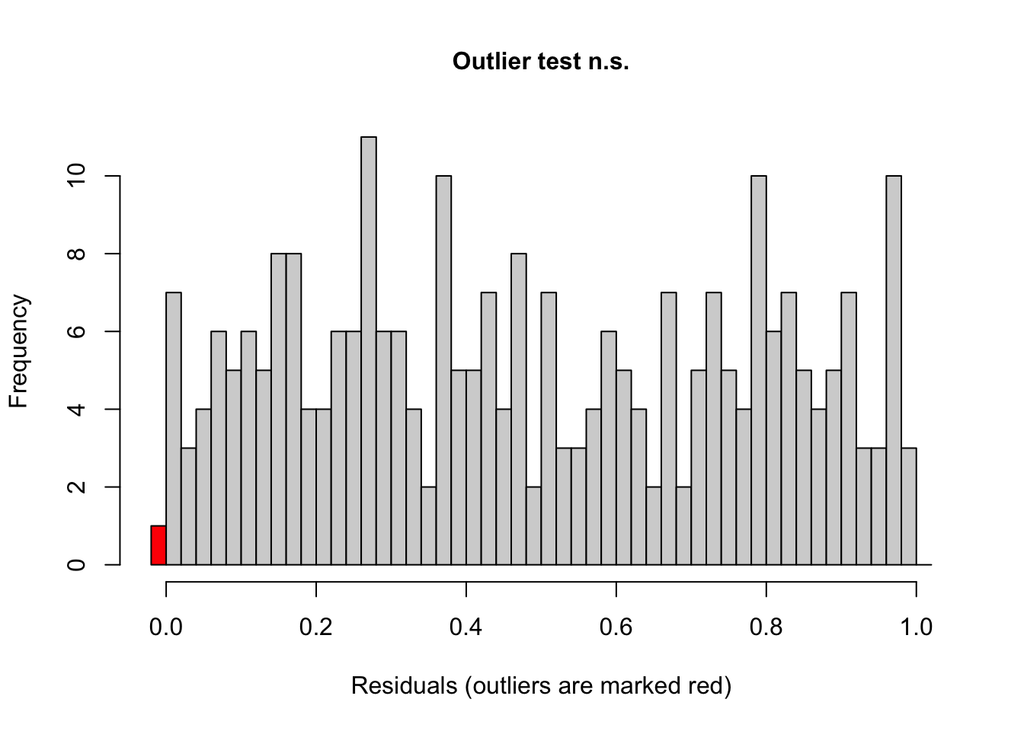

```
##
##  DHARMa outlier test based on exact binomial test with approximate
##  expectations
##
## data:  gam1_glmm_au
## outliers at both margin(s) = 1, observations = 270, p-value = 0.7298
## alternative hypothesis: true probability of success is not equal to 0.007968127
## 95 percent confidence interval:
##  9.376526e-05 2.046186e-02
## sample estimates:
## frequency of outliers (expected: 0.00796812749003984 )
##                                            0.003703704
```

```r
# test for outliers
testOutliers(gam1_glmm_au, plot=T)
```

The model appears to fit the number of outliers well, as the significance values is 0.7298 (p>0.05), indicating no significant outlier problem. The observed frequency of outliers was 0.00370, which is less than the expected frequence of 0.00797.

### 5.3.3 Additional tests

There are no 0s present in the data, so it is not appropriate to test for 0 inflation. Additionally, there is no temporal or spatial data for each observation so it is not possible to test for autocorrelation.

### 5.3.4 Model preditive performance

An important step in assessing the fit of a model is investigating its predictive performance. To that end, the `predict()` function was used to produce body mass estimates based on inputted predictor variables, which were then plotted against the actual recorded body mass measurements.

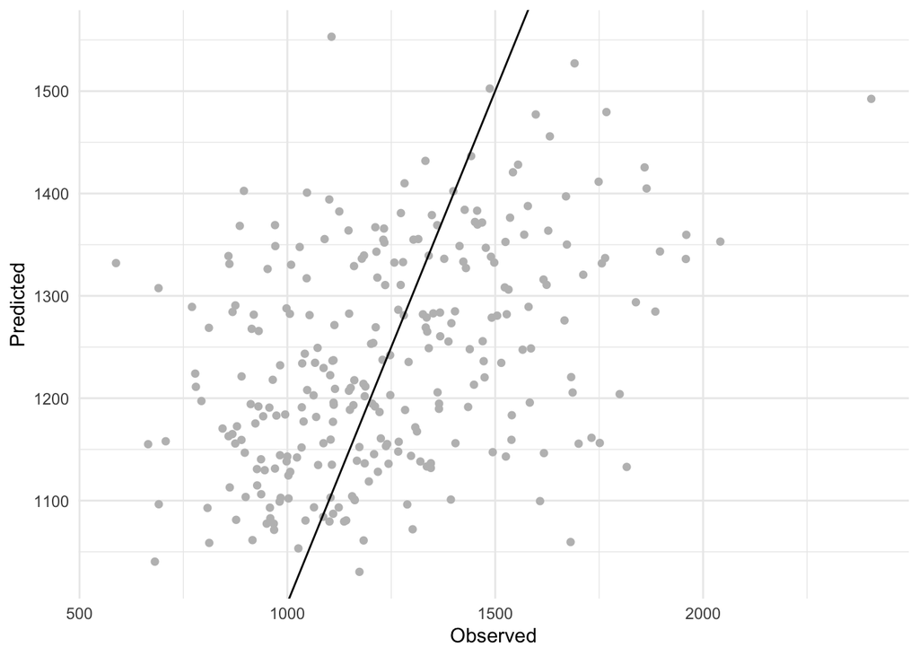

```r
# add predicted values column to data frame
extdrop_au$predicted <- predict(gam1_glmm_au,
                                data = extdrop_au,
                                type = "response")

# plot predicted values against actual values
ggplot(extdrop_au, aes(x = body_mass,
                       y = predicted)) +
  geom_point(col="grey") +
  geom_abline(slope = 1) +
  theme_minimal() +
  xlab("Observed") +
  ylab("Predicted")
```

If the model were able to accurately predict body mass, the points should fall close to the line. As this is not the case the current model has poor predictive performance. This limitation will be discussed further in section 7 “Discussion”.

## 5.4 Model adjustment

### 5.4.1 Random slope effects

There might be differences in the effect of variables as recorded by each observer so random slope effects were added for each predictor variable.

```r
# define gamma glmm and select fixed and random effects
gam2_glmm_au <- glmmTMB(body_mass ~ landscape +
                          vegetation +
                          lion_presence +
                          aar +
                          dtw +
                          pd +
                          vegetation:aar +
                          lion_presence:pd +
                          (1+landscape|observer) +
                          (1+vegetation|observer) +
                          (1+lion_presence|observer) +
                          (1+aar|observer) +
                          (1+dtw|observer) +
                          (1+pd|observer),
                        # input extreme value drop data
                        data = extdrop_au,
                        # select gamma as the distribution with log as the link function
                        family = Gamma(link = "log"))
```

Unfortunately, this model failed to converge due to an insufficient quantity of data for the number of random effects. This remained an issue, even when testing random slope individually.

### 5.4.2 Alternative error structures

At this point, the lognormal distribution was re-evaluated as it is biologically justifiable since body mass in mammals follows a multiplicative growth process where proportional increases in mass decrease with body size, making a lognormal distribution appropriate. Therefore, the following model was constructed, then assessed.

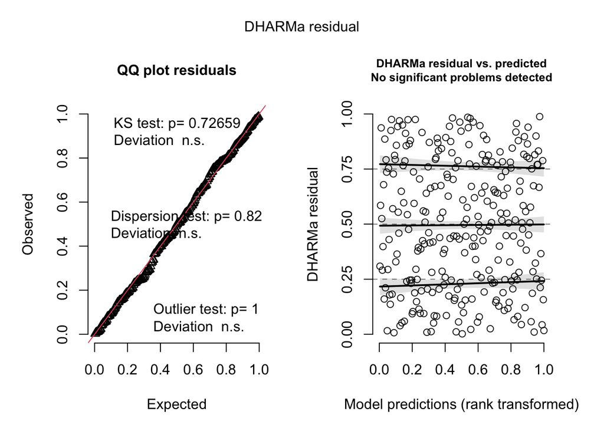

```r
# define lognormal glmm
logn1_glmm_au <- glmmTMB(log(body_mass) ~ landscape +
                           vegetation +
                           lion_presence +
                           aar +
                           dtw +
                           pd +
                           vegetation:aar +
                           lion_presence:pd +
                           (1|observer),
                        data = extdrop_au,
                        family = "lognormal")

### see previous code annotations ###

logn1_sim_au <- simulateResiduals(logn1_glmm_au, n = 1000, plot=T)
```

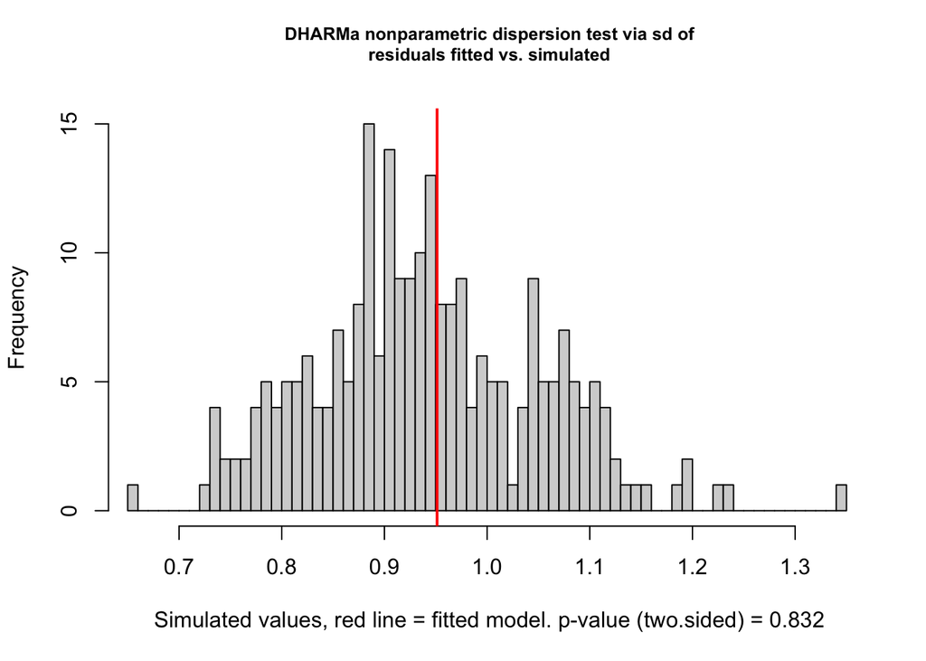

```
##
##  DHARMa nonparametric dispersion test via sd of residuals fitted vs.
##  simulated
##
## data:  simulationOutput
## dispersion = 1.0104, p-value = 0.832
## alternative hypothesis: two.sided
```

```r
testDispersion(logn1_glmm_au, plot=T)
```

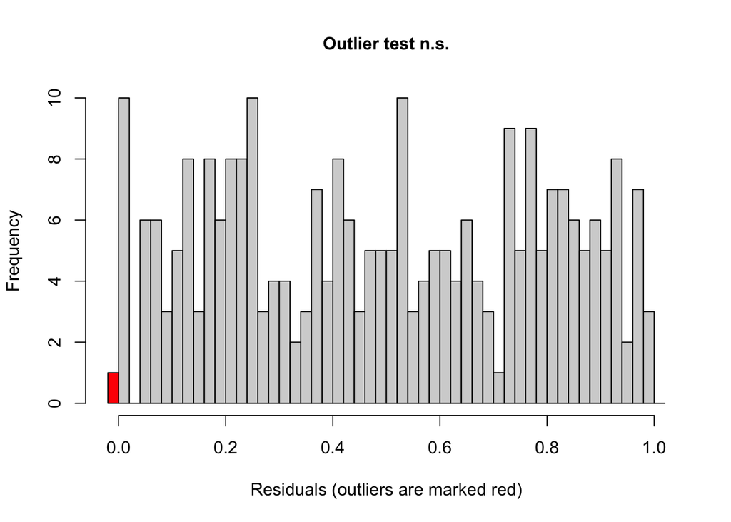

```
##
##  DHARMa outlier test based on exact binomial test with approximate
##  expectations
##
## data:  logn1_glmm_au
## outliers at both margin(s) = 1, observations = 270, p-value = 0.7298
## alternative hypothesis: true probability of success is not equal to 0.007968127
## 95 percent confidence interval:
##  9.376526e-05 2.046186e-02
## sample estimates:
## frequency of outliers (expected: 0.00796812749003984 )
##                                            0.003703704
```

```r
testOutliers(logn1_glmm_au, plot=T)
```

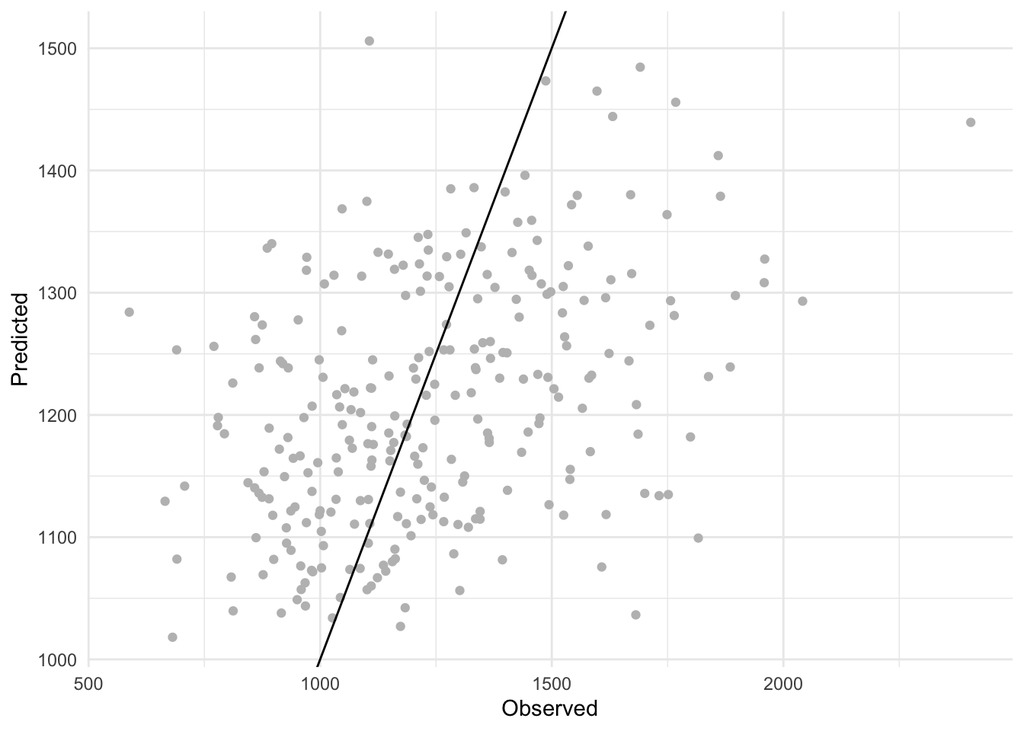

```r
extdrop_au$logn_predicted <- exp(predict(logn1_glmm_au,
                                         type = "response"))
ggplot(extdrop_au, aes(x = body_mass,
                       y = logn_predicted)) +
  geom_point(col="grey") +
  geom_abline(slope = 1) +
  theme_minimal() +
  xlab("Observed") +
  ylab("Predicted")
```

### 5.4.3 Model comparison

As the `gam1_glmm_au` model has body_mass as its response variable and `logn1_glmm_au` has log(body_mass) instead, it is not possible to compare the two using ANOVA and AIC values. Instead, performance in model assessment tests were compared to see which performed better overall. When comparing their reults with DHARMa residuals, `logn1_glmm_au` performed better, with less observed deviation in observed values compared to expected. `logn1_glmm_au` also performed better in the dispersion test with 1.0104 (p = 0.83), compared to 1.0314 (p = 0.76) as produced by the `gam1_glmm_au` model. Overall, differences were miniscule but as the performance of `logn1_glmm_au` was slightly better, this model was brought forward.

# 6 Model output

## 6.1 Results

The `parameters()` function was used to return the coefficient, standard error, 95% confidence interval, z value , and p value for each of the fixed effect predictor variables. Because a lognormal distribution was used, the response variable was log transformed and any outputs therefore need to be exponentiated.

```r
# retrieve fixed effect coefficients, standard error, CI, z, and p values
parameters(logn1_glmm_au, effect="fixed", exponentiate=TRUE, digits=3)
```

```
## # Fixed Effects
##
## Parameter                    | Coefficient |    SE |         95% CI |       z |      p
## --------------------------------------------------------------------------------------
## (Intercept)                  |       7.130 | 0.043 | [7.046, 7.216] | 323.100 | < .001
## landscape [Hilly]            |       0.994 | 0.004 | [0.986, 1.001] |  -1.700 | 0.089
## vegetation [Open]            |       0.995 | 0.004 | [0.988, 1.002] |  -1.345 | 0.179
## lion presence [Present]      |       1.002 | 0.004 | [0.995, 1.010] |   0.617 | 0.537
## aar                          |       0.995 | 0.003 | [0.990, 1.001] |  -1.734 | 0.083
## dtw                          |       1.004 | 0.002 | [1.000, 1.008] |   2.011 | 0.044
## pd                           |       1.000 | 0.002 | [0.995, 1.004] |  -0.150 | 0.881
## vegetation [Open] × aar      |       1.003 | 0.004 | [0.996, 1.011] |   0.854 | 0.393
## lion presence [Present] × pd |       1.001 | 0.004 | [0.993, 1.008] |   0.135 | 0.893
```

Of the predictor variables examined, only distance to water significantly affected body mass (β = 1.004, SE = 0.002, z = 2.011, p = 0.044), with mass increasing with distance. Landscape type (p = 0.089) and average annual rainfall (p = 0.083) showed marginal trends but were not statistically significant. No other predictors or interactions significantly impacted body mass.

To retrieve model summary statistics and information on the `observer` random effect involvement, the `summary()` function was used. R<sup>2</sup> values were calculated using the `r.squaredGLMM` function from the `MuMIn package`, allowing for the estimation of variance accounted for by fixed and total combined effects.

```r
# summarise model statistics
summary(logn1_glmm_au)
```

```
##  Family: lognormal  ( log )
## Formula:
## log(body_mass) ~ landscape + vegetation + lion_presence + aar +
##     dtw + pd + vegetation:aar + lion_presence:pd + (1 | observer)
## Data: extdrop_au
##
##       AIC       BIC    logLik -2*log(L)  df.resid
##     -21.9      17.7      21.9     -43.9       259
##
## Random effects:
##
## Conditional model:
##  Groups   Name        Variance  Std.Dev.
##  observer (Intercept) 0.0001111 0.01054
## Number of obs: 270, groups:  observer, 5
##
## Dispersion parameter for lognormal family (): 0.219
##
## Conditional model:
##                           Estimate Std. Error z value Pr(>|z|)
## (Intercept)              1.9643799  0.0060798   323.1   <2e-16 ***
## landscapeHilly          -0.0065060  0.0038271    -1.7   0.0891 .
## vegetationOpen          -0.0050941  0.0037872    -1.3   0.1786
## lion_presencePresent     0.0023838  0.0038612     0.6   0.5370
## aar                     -0.0047680  0.0027491    -1.7   0.0829 .
## dtw                      0.0038291  0.0019039     2.0   0.0443 *
## pd                      -0.0003694  0.0024629    -0.2   0.8808
## vegetationOpen:aar       0.0032622  0.0038193     0.9   0.3930
## lion_presencePresent:pd  0.0005264  0.0038976     0.1   0.8926
## ---
## Signif. codes:  0 '***' 0.001 '**' 0.01 '*' 0.05 '.' 0.1 ' ' 1
```

```r
# calculate r-squared values for glmm
r.squaredGLMM(logn1_glmm_au)
```

```
##               R2m         R2c
## [1,] 0.0009279099 0.003233664
```

## 6.2 Visualisation

The model outputs were tidied using the `tidy()` function from the `broom.mixed` package, filtered, and then presented in a dot and whisker plot to show their coefficient estimates.

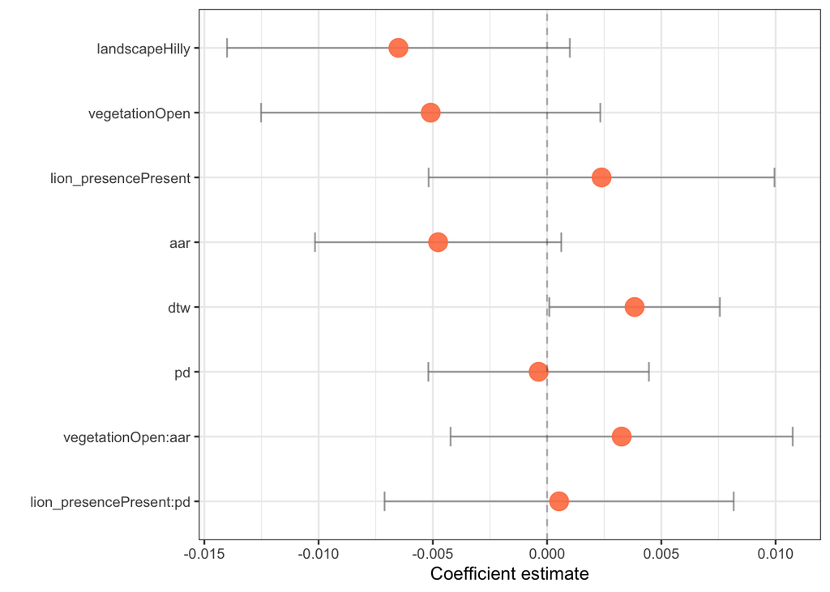

```r
# reshape model outputs into tidy format
results_au <- broom.mixed::tidy(logn1_glmm_au, conf.int = TRUE) %>%
  # clean up the random effect names
  mutate(term=ifelse(grepl("sd__(Int",term,
                           fixed=TRUE),
                     paste(group,term,sep="."),
                     term))

# filter and sort data
sorted_au <-results_au %>%
  filter(effect=="fixed") %>%
  filter(term!="(Intercept)") %>%
  mutate(term=factor(term, levels = rev(term)))

# plot sorted results
ggplot(sorted_au, aes(x=estimate, y=term)) +
  geom_errorbar(aes(xmin=conf.low, xmax=conf.high),
                width=0.3,
                col="grey50",
                alpha=0.7) +
  geom_point(col="coral", size=5, alpha=0.9) +
  geom_vline(xintercept=0, lty="dashed", alpha=0.3) +
  theme_bw() +
  ylab("") +
  xlab("Coefficient estimate")
```

The predicted effect of distance to water on body mass was estimated using the `ggpredict()` function and plotted because it was the only predictor found to have a signficant effect. Because the continuous variables are scaled in the model, they had to first be converted back to their original scale before plotting.

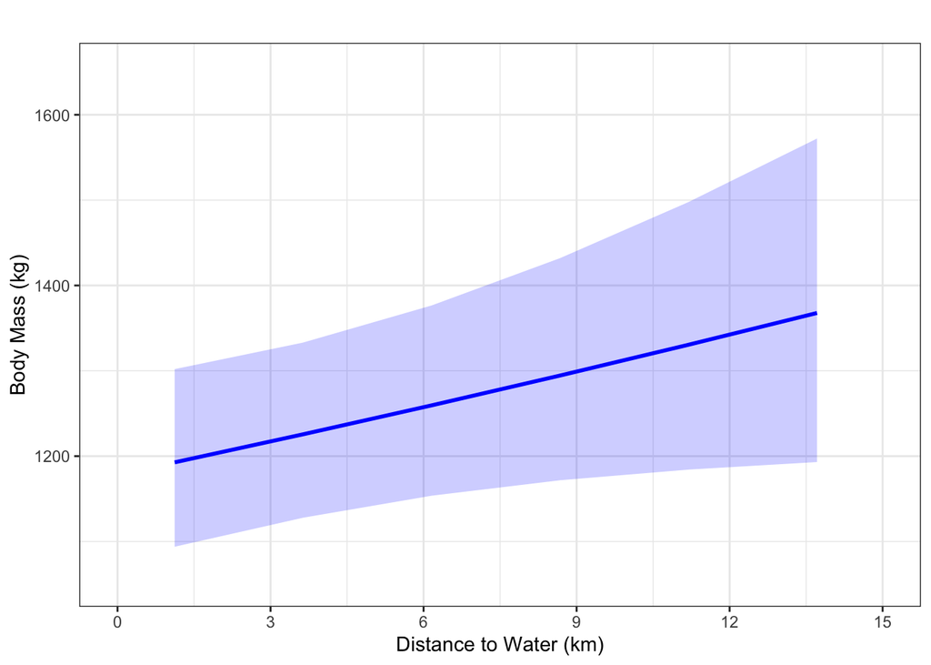

```r
# get scaling parameters
mean_dtw <- mean(extdrop_au$distance_to_water_km)
sd_dtw <- sd(extdrop_au$distance_to_water_km)

# use ggpredict to get predictions
pred_dtw <- ggpredict(logn1_glmm_au, terms = "dtw")

# convert back to original scale
pred_dtw$distance_km <- pred_dtw$x * sd_dtw + mean_dtw

# plot with original scale
ggplot(pred_dtw, aes(x = distance_km, y = predicted)) +
  geom_line(color = "blue", linewidth = 1) +
  geom_ribbon(aes(ymin = conf.low, ymax = conf.high),
              alpha = 0.2, fill = "blue") +
  scale_x_continuous(limits = c(0, 15),
                     breaks = seq(0, 15, by = 3)) +
  labs(x = "Distance to Water (km)",
       y = "Body Mass (kg)",
       title = "") +
  theme_bw()
```

Group level effects were estimated using the `estimate_grouplevel()` function from the `modelbased` package and visualised, demonstrating observer effect on coefficient values.

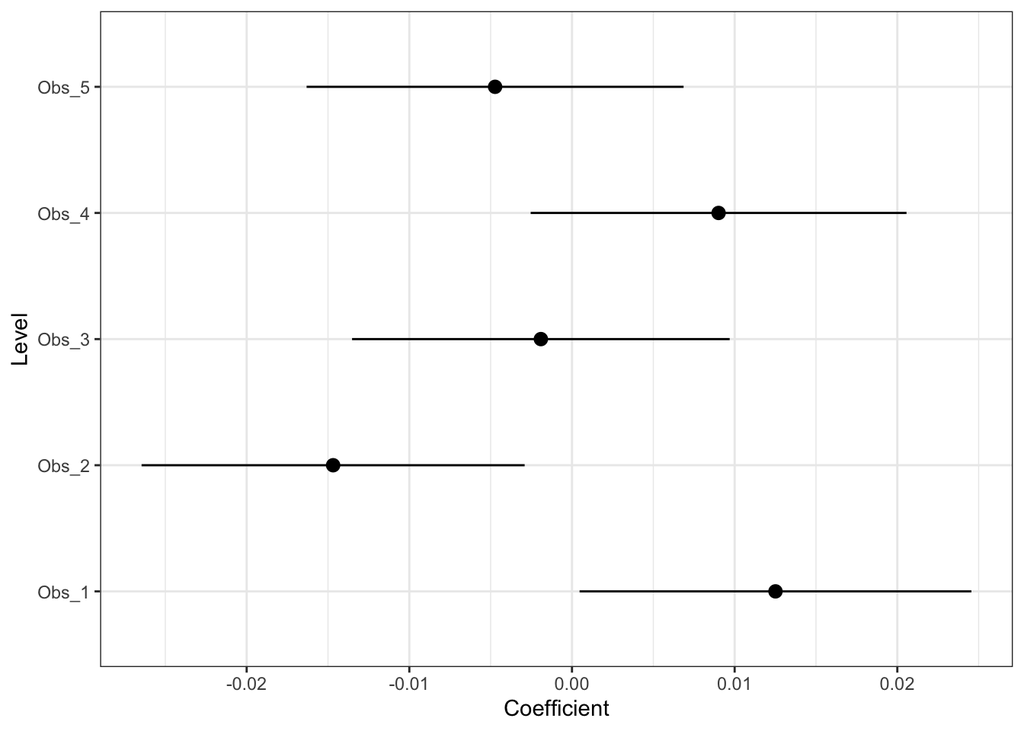

```r
# define new group level effects object
gle_au <- estimate_grouplevel(logn1_glmm_au)

# plot group level effects
plot(gle_au) +
  theme_bw()
```

# 7 Discussion

With the data available, it was only possible to determine one variable as a significant predictor of body mass, with increased body mass being predicted by distance from a water source. This is a somewhat unexpected result, and difficult to explain. It was considered whether predators are more likely to hunt near sources of water but predator density didn’t have a significant effect on body mass. One potential explanation is that there could be less competition from other Giraffes, further from sources of water. This cannot be said for certain without more information, such as population density data.

Ultimately, it is clear that the model is incomplete from its predictive capacity as well as the presence of unexplained variance. Giraffe body mass varies with age, sex, stage of pregnancy (if relevant), and even time of day, not to mention inter-individual differences, (Mitchell, 2021). There are also a number of other environmental factors that are missing from the present dataset. Additionally, temporal and spatial data would be incredibly useful in compensating for autocorrelation, and a greater number of observations with inclusion of additional sites would be required to better define random errors.

# 8 References

Cerini, F., Childs, D.Z. and Clements, C.F. (2023) ‘A predictive timeline of wildlife population collapse’, Nature Ecology & Evolution, 7(3), pp. 320–331. Available at: https://doi.org/10.1038/s41559-023-01985-2.  
Clements, C.F. and Ozgul, A. (2016) ‘Including trait-based early warning signals helps predict population collapse’, Nature Communications, 7(1), p. 10984. Available at: https://doi.org/10.1038/ncomms10984.  
Cleveland, W.S. (1993) Visualizing data. Murray Hill, NJ: AT & T Bell Laboratories.  
Herbison, L. and Frame, G.W. (2025) ‘giraffe’, Encyclopaedia Britannica. Online Edition. Encyclopaedia Britannica, Inc. Available at: https://www.britannica.com/animal/giraffe (Accessed: 16 December 2025).  
Mitchell, G. (2021) ‘Notes on Allometry and Prediction of Body Mass and Age of Giraffes’, in Mitchell, G., How Giraffes Work. Oxford University Press, pp. 76–84. Available at: https://doi.org/10.1093/oso/9780197571194.003.0005.  
Santon, M. et al. (2023) ‘A versatile workflow for linear modelling in R’, Frontiers in Ecology and Evolution, 11, p. 1065273. Available at: https://doi.org/10.3389/fevo.2023.1065273.